# Predicting Highway Construction Contract Costs

Lindsey Carothers

September 2026

**Can historical project characteristics help predict the cost of a highway construction project, and what factors have the strongest relationship with cost?**

# Project Overview

Accurately estimating construction costs helps transportation agencies plan budgets, allocate funding, and evaluate projects. In this project, I used public data from the Texas Department of Transportation (TxDOT) to explore what factors are related to highway construction costs and whether those factors can be used to predict costs for new projects.

I focused on three main questions:

1. What project characteristics are related to higher construction costs?
2. How accurately can these characteristics predict project cost?
3. How well does the model perform when it is tested on projects it has not seen before?

# Data

The data comes from the Texas Department of Transportation’s public Project Information dataset.

```r
library(readr)

# Read in the TxDOT project data
txdot <- read_csv("txdot_projects.csv")

# Check the number of rows and columns in the original data
dim(txdot)
```

```
## [1] 8711   61
```

The original dataset contains 8711 project records and 61 variables.

## Selecting Relevant Variables

The original dataset contains many variables, so I narrowed it down to information that could be useful for understanding or predicting project cost.

```r
# Keep the variables that are most relevant to the analysis
# Rename them to make them easier to work with in R
projects <- txdot |>
  select(
    project_id = `PROJECT ID`,
    district = `DISTRICT/ DIVISION`,
    county = COUNTY,
    project_type = `PROJECT TYPE`,
    project_class = `PROJECT CLASSIFICATION`,
    type_of_work = `TYPE OF WORK`,
    working_days = `MAXIMUM NUMBER OF WORKING DAYS`,
    road_length = `PROPOSED MAINLANE LENGTH`,
    project_cost = `PROJECT ESTIMATE / LOW BID`,
    engineer_estimate = `SEALED ENGINEER'S ESTIMATE PROJECT`,
    actual_let_date = `PROJECT ACTUAL LET DATE`
  )
```

# Data Preparation

Before starting the analysis, I cleaned the variables used in the project. Numeric variables were converted to numbers, categorical variables were converted to factors, and observations without the information needed for the model were removed.

```r
projects <- projects |>
  mutate(
    # Convert cost, duration, and road length variables to numeric
    project_cost = as.numeric(project_cost),
    engineer_estimate = as.numeric(engineer_estimate),
    working_days = as.numeric(working_days),
    road_length = as.numeric(road_length),

    # Treat these variables as categories
    district = factor(district),
    project_type = factor(project_type),
    project_class = factor(project_class)
  ) |>
  filter(
    # Remove projects without usable cost or predictor information
    !is.na(project_cost),
    project_cost > 0,
    !is.na(working_days),
    working_days > 0,
    !is.na(road_length),
    !is.na(district),
    !is.na(project_type)
  )
```

```r
# Check the size of the cleaned dataset
dim(projects)
```

```
## [1] 3020   11
```

```r
# Get a quick summary of project costs
summary(projects$project_cost)
```

```
##      Min.   1st Qu.    Median      Mean   3rd Qu.      Max.
## 1.000e+00 2.416e+05 6.062e+05 7.391e+06 2.000e+06 1.298e+09
```

After cleaning, the dataset contains 3020 projects that can be used in the analysis.

# Exploratory Analysis

Before building the model, I first looked at the data to better understand the range of project costs and how cost relates to different project characteristics.

## Distribution of Project Costs

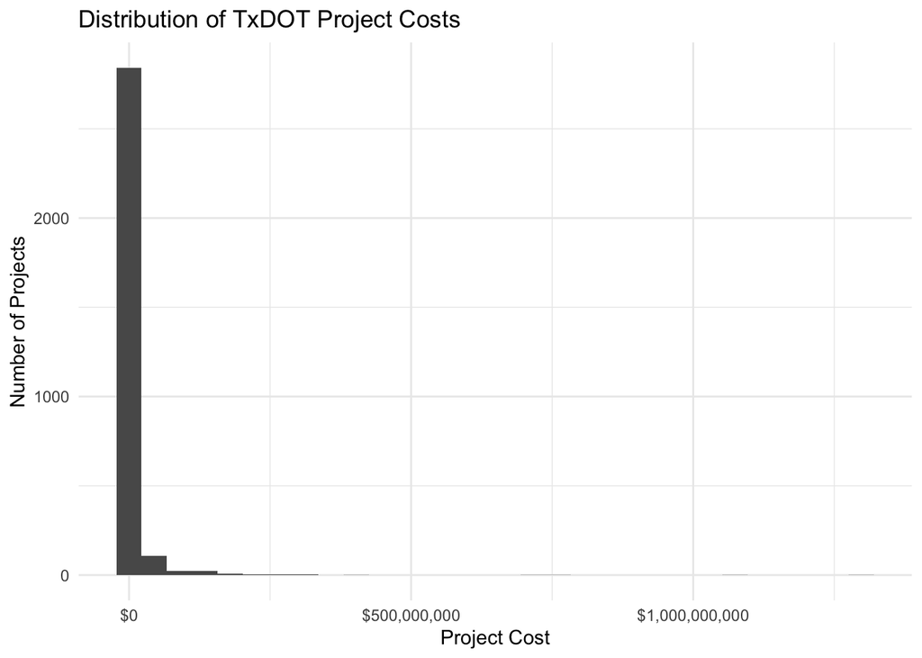

```r
# Look at how project costs are distributed
ggplot(projects, aes(x = project_cost)) +
  geom_histogram(bins = 30) +
  scale_x_continuous(labels = dollar_format()) +
  labs(
    title = "Distribution of TxDOT Project Costs",
    x = "Project Cost",
    y = "Number of Projects"
  ) +
  theme_minimal()
```

There is a wide range of project costs, with a smaller number of very expensive projects creating a strong right skew. This is something I will account for when building the regression model.

## Project Cost and Expected Duration

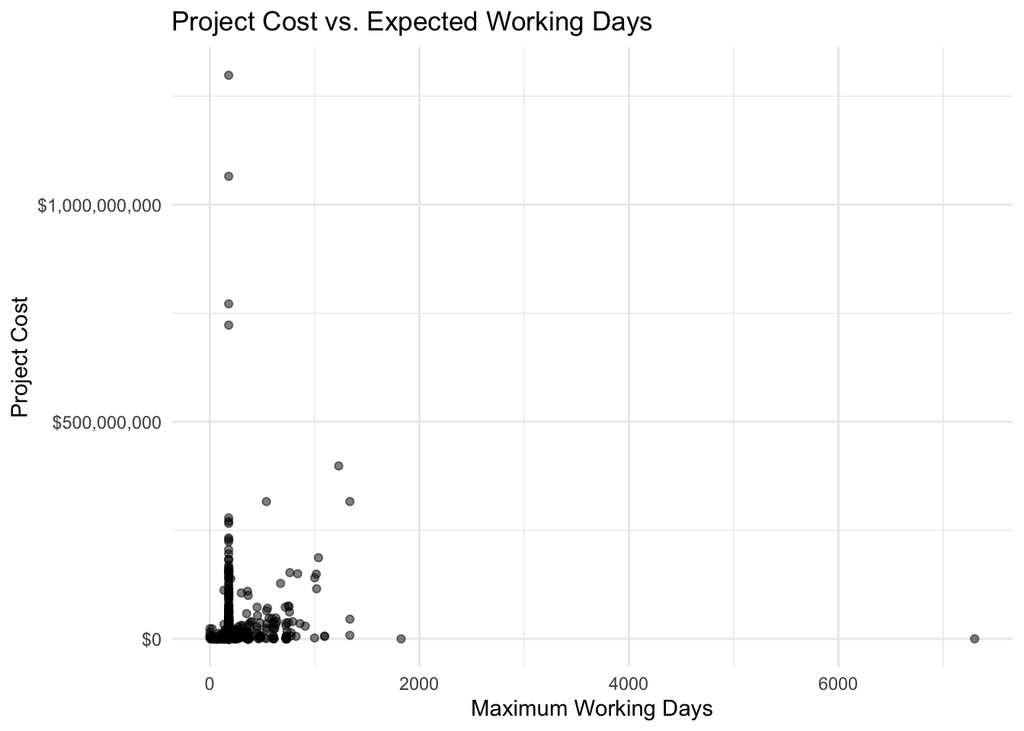

```r
# Compare project duration with project cost
ggplot(projects, aes(x = working_days, y = project_cost)) +
  geom_point(alpha = 0.5) +
  scale_y_continuous(labels = dollar_format()) +
  labs(
    title = "Project Cost vs. Expected Working Days",
    x = "Maximum Working Days",
    y = "Project Cost"
  ) +
  theme_minimal()
```

This plot helps show whether projects expected to take longer also tend to cost more.

## Project Cost by Project Type

```r
# Compare the typical cost of different project types
projects |>
  group_by(project_type) |>
  summarise(
    projects = n(),
    median_cost = median(project_cost, na.rm = TRUE),
    mean_cost = mean(project_cost, na.rm = TRUE)
  ) |>
  arrange(desc(median_cost))
```

```
## # A tibble: 7 × 4
##   project_type         projects median_cost  mean_cost
##   <fct>                   <int>       <dbl>      <dbl>
## 1 Alternative Delivery        2  180930461  180930461
## 2 Joint Bid Utility           4    7121172.   8473366.
## 3 Construction             2115     756000    9966489.
## 4 Transfer                    1     488934     488934
## 5 Feasibility Study           6     407820     461832.
## 6 Non-Let                    89     404400    2092316.
## 7 Maintenance               803     400000     816009.
```

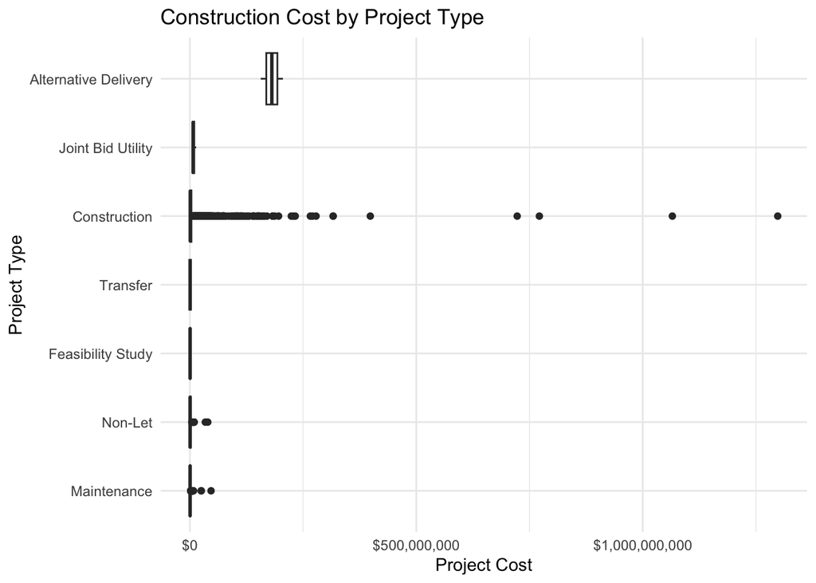

```r
# Visualize the range of costs within each project type
projects |>
  filter(!is.na(project_type)) |>
  ggplot(
    aes(
      x = reorder(project_type, project_cost, median),
      y = project_cost
    )
  ) +
  geom_boxplot() +
  coord_flip() +
  scale_y_continuous(labels = dollar_format()) +
  labs(
    title = "Construction Cost by Project Type",
    x = "Project Type",
    y = "Project Cost"
  ) +
  theme_minimal()
```

# Engineer Estimate Analysis

I also wanted to see how the engineer’s estimate compares with the project cost recorded in the dataset. For projects with an available engineer’s estimate, I calculated both the dollar difference and percentage difference between the two values.

```r
estimate_projects <- projects |>
  # Only use projects that have a usable engineer estimate
  filter(
    !is.na(engineer_estimate),
    engineer_estimate > 0
  ) |>
  mutate(
    # Calculate how far project cost is from the engineer estimate
    estimate_difference = project_cost - engineer_estimate,

    # Calculate the difference as a percentage of the engineer estimate
    estimate_difference_pct =
      (project_cost - engineer_estimate) / engineer_estimate
  )
```

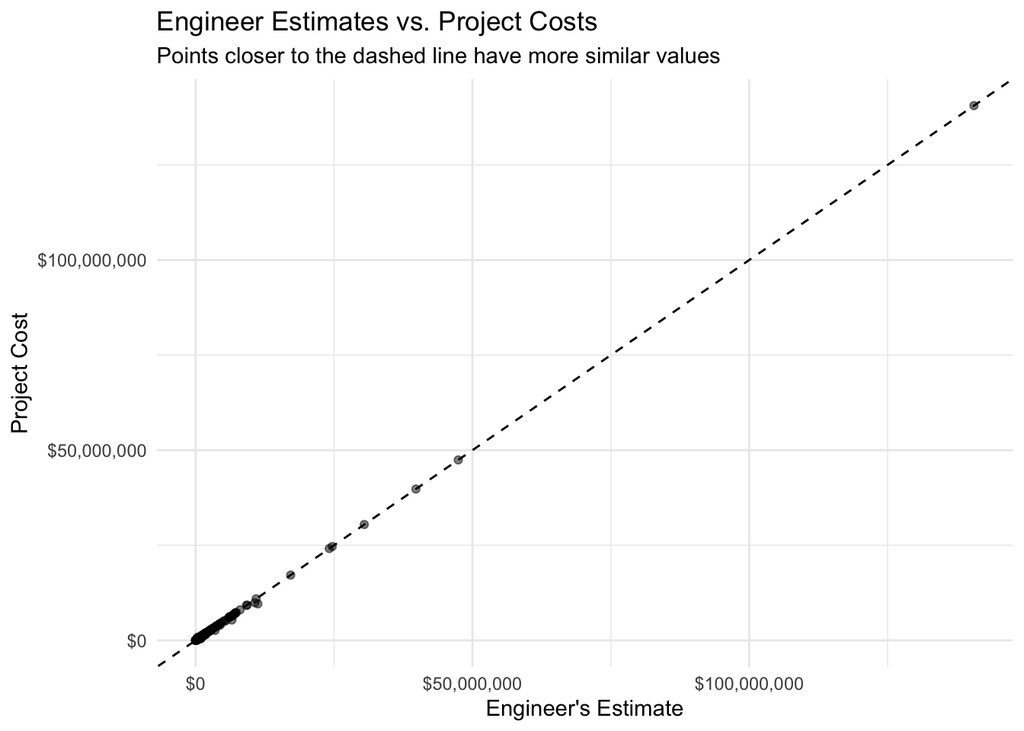

```r
# Compare engineer estimates with recorded project costs
ggplot(
  estimate_projects,
  aes(x = engineer_estimate, y = project_cost)
) +
  geom_point(alpha = 0.5) +
  geom_abline(
    intercept = 0,
    slope = 1,
    linetype = "dashed"
  ) +
  scale_x_continuous(labels = dollar_format()) +
  scale_y_continuous(labels = dollar_format()) +
  labs(
    title = "Engineer Estimates vs. Project Costs",
    subtitle = "Points closer to the dashed line have more similar values",
    x = "Engineer's Estimate",
    y = "Project Cost"
  ) +
  theme_minimal()
```

```r
# Summarize the percentage difference between the two values
summary(estimate_projects$estimate_difference_pct)
```

```
##     Min.  1st Qu.   Median     Mean  3rd Qu.     Max.
## -0.57634  0.00000  0.00000 -0.01325  0.00000  1.27489
```

# Predictive Modeling

Next, I built a regression model to see how well project characteristics could predict project cost.

I randomly divided the data into a **70% training set** and a **30% validation set**. The training data is used to build the model, while the validation data gives me a way to test the model on projects it has not seen before.

```r
# Set a seed so the same random split can be reproduced
set.seed(1234)

# Randomly select 70% of the rows for training
train_index <- sample(
  1:nrow(projects),
  size = round(0.70 * nrow(projects)),
  replace = FALSE
)

# Create the training and validation datasets
train <- projects[train_index, ]
valid <- projects[-train_index, ]

# Check how many observations are in each set
nrow(train)
```

```
## [1] 2114
```

```r
nrow(valid)
```

```
## [1] 906
```

## Baseline Regression Model

The initial model includes project duration, roadway length, project type, and district.

Since project costs are strongly right-skewed, I modeled the natural logarithm of project cost instead of using the raw dollar amounts. This reduces the influence of extremely expensive projects and makes the data more suitable for regression.

```r
# Build the initial regression model using the training data
model_full <- lm(
  log(project_cost) ~
    working_days +
    road_length +
    project_type +
    district,
  data = train
)

# Review the model results
summary(model_full)
```

```
##
## Call:
## lm(formula = log(project_cost) ~ working_days + road_length +
##     project_type + district, data = train)
##
## Residuals:
##      Min       1Q   Median       3Q      Max
## -14.7084  -0.9732   0.1541   1.4299   7.5787
##
## Coefficients:
##                                 Estimate Std. Error t value Pr(>|t|)
## (Intercept)                   19.0132493  1.8445530  10.308  < 2e-16 ***
## working_days                   0.0010820  0.0002799   3.866 0.000114 ***
## road_length                    0.0078993  0.0058941   1.340 0.180324
## project_typeConstruction      -4.3026465  1.7815066  -2.415 0.015813 *
## project_typeFeasibility Study -6.4526617  2.2852995  -2.824 0.004795 **
## project_typeJoint Bid Utility -4.8063112  2.1770735  -2.208 0.027374 *
## project_typeMaintenance       -7.2499797  1.7844352  -4.063 5.03e-05 ***
## project_typeNon-Let           -6.0301468  1.8084581  -3.334 0.000870 ***
## project_typeTransfer          -5.0737728  3.0454312  -1.666 0.095858 .
## districtAmarillo              -0.9778602  0.5357145  -1.825 0.068093 .
## districtAtlanta               -1.6863337  0.5129197  -3.288 0.001027 **
## districtAustin                 1.0010667  0.5683470   1.761 0.078323 .
## districtBeaumont              -1.1130365  0.5149388  -2.161 0.030771 *
## districtBrownwood             -2.0450166  0.5154746  -3.967 7.52e-05 ***
## districtBryan                 -0.2176978  0.6041218  -0.360 0.718619
## districtChildress             -0.5725070  0.7632749  -0.750 0.453299
## districtCorpus Christi         1.4575246  0.8122484   1.794 0.072889 .
## districtDallas                -1.0354152  0.5067340  -2.043 0.041147 *
## districtEl Paso               -0.9861386  0.6556069  -1.504 0.132692
## districtFort Worth            -0.7232608  0.5114891  -1.414 0.157503
## districtHouston                0.7274115  0.4999270   1.455 0.145810
## districtLaredo                -0.4156349  0.5412611  -0.768 0.442633
## districtLubbock                0.9611643  0.9126682   1.053 0.292401
## districtLufkin                 1.2743647  0.6771939   1.882 0.059998 .
## districtOdessa                -0.7917824  0.7048703  -1.123 0.261439
## districtParis                  0.6731445  0.6325167   1.064 0.287347
## districtPharr                  2.0059230  0.7669760   2.615 0.008978 **
## districtSan Angelo             0.6186104  0.7078979   0.874 0.382290
## districtSan Antonio           -0.0866336  0.5277381  -0.164 0.869621
## districtTyler                  0.8593381  0.7003265   1.227 0.219941
## districtWaco                  -0.1630126  0.5801117  -0.281 0.778737
## districtWichita Falls         -4.7484182  0.9483589  -5.007 5.99e-07 ***
## districtYoakum                -3.2488419  0.5011782  -6.482 1.12e-10 ***
## ---
## Signif. codes:  0 '***' 0.001 '**' 0.01 '*' 0.05 '.' 0.1 ' ' 1
##
## Residual standard error: 2.464 on 2081 degrees of freedom
## Multiple R-squared:  0.2978, Adjusted R-squared:  0.287
## F-statistic: 27.58 on 32 and 2081 DF,  p-value: < 2.2e-16
```

# Model Selection

I used backward selection with AIC to simplify the initial model. The process starts with all of the predictors and removes variables when doing so improves the balance between model fit and complexity.

```r
# Use backward selection to find a simpler final model
model_final <- step(
  model_full,
  direction = "backward",
  trace = 0
)

# Review the final model
summary(model_final)
```

```
##
## Call:
## lm(formula = log(project_cost) ~ working_days + project_type +
##     district, data = train)
##
## Residuals:
##      Min       1Q   Median       3Q      Max
## -14.7485  -0.9844   0.1559   1.4198   7.5725
##
## Coefficients:
##                                 Estimate Std. Error t value Pr(>|t|)
## (Intercept)                   19.0517781  1.8446815  10.328  < 2e-16 ***
## working_days                   0.0010776  0.0002799   3.850 0.000122 ***
## project_typeConstruction      -4.3015420  1.7818470  -2.414 0.015860 *
## project_typeFeasibility Study -6.4301508  2.2856747  -2.813 0.004951 **
## project_typeJoint Bid Utility -4.8227919  2.1774550  -2.215 0.026876 *
## project_typeMaintenance       -7.2821708  1.7846147  -4.081 4.66e-05 ***
## project_typeNon-Let           -6.0560508  1.8087005  -3.348 0.000828 ***
## project_typeTransfer          -5.1049186  3.0459248  -1.676 0.093892 .
## districtAmarillo              -0.9664188  0.5357488  -1.804 0.071397 .
## districtAtlanta               -1.6937354  0.5129880  -3.302 0.000977 ***
## districtAustin                 0.9879118  0.5683709   1.738 0.082333 .
## districtBeaumont              -1.1230345  0.5149832  -2.181 0.029316 *
## districtBrownwood             -2.0403105  0.5155612  -3.957 7.83e-05 ***
## districtBryan                 -0.2413872  0.6039786  -0.400 0.689447
## districtChildress             -0.5669671  0.7634096  -0.743 0.457761
## districtCorpus Christi         1.4433214  0.8123345   1.777 0.075754 .
## districtDallas                -1.0408424  0.5068147  -2.054 0.040130 *
## districtEl Paso               -0.9507753  0.6552009  -1.451 0.146897
## districtFort Worth            -0.7279335  0.5115750  -1.423 0.154907
## districtHouston                0.7165061  0.4999564   1.433 0.151969
## districtLaredo                -0.4119108  0.5413575  -0.761 0.446812
## districtLubbock                0.9506724  0.9128091   1.041 0.297774
## districtLufkin                 1.2708260  0.6773182   1.876 0.060759 .
## districtOdessa                -0.8002935  0.7049765  -1.135 0.256420
## districtParis                  0.6678206  0.6326252   1.056 0.291258
## districtPharr                  1.9944423  0.7670748   2.600 0.009387 **
## districtSan Angelo             0.6041380  0.7079508   0.853 0.393557
## districtSan Antonio           -0.0977708  0.5277736  -0.185 0.853050
## districtTyler                  0.8514614  0.7004358   1.216 0.224269
## districtWaco                  -0.1241914  0.5794988  -0.214 0.830328
## districtWichita Falls         -4.7434130  0.9485329  -5.001 6.19e-07 ***
## districtYoakum                -3.2518993  0.5012688  -6.487 1.09e-10 ***
## ---
## Signif. codes:  0 '***' 0.001 '**' 0.01 '*' 0.05 '.' 0.1 ' ' 1
##
## Residual standard error: 2.464 on 2082 degrees of freedom
## Multiple R-squared:  0.2972, Adjusted R-squared:  0.2867
## F-statistic:  28.4 on 31 and 2082 DF,  p-value: < 2.2e-16
```

# Model Diagnostics

Before evaluating predictions, I reviewed the regression diagnostic plots to look for possible problems with the model.

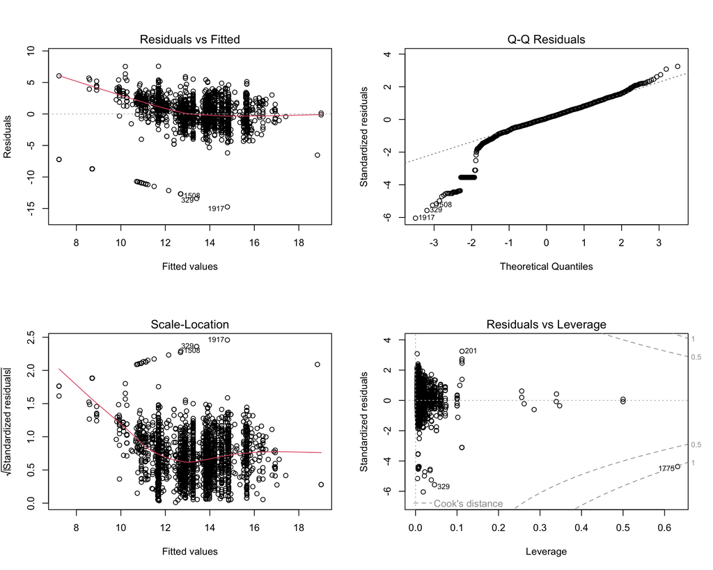

```r
# Set up the plotting window to show four plots
par(mfrow = c(2, 2))

# Display the standard regression diagnostic plots
plot(model_final)
```

```r
# Return to the normal one-plot layout
par(mfrow = c(1, 1))
```

These plots help check whether the model’s errors behave reasonably and whether there are unusual observations or patterns that could affect the results.

# Out-of-Sample Validation

Now I can test the model using the 30% validation sample that was not used to build it.

A few validation projects contain district categories that were not present in the training data. Since the model has never seen those categories, they are removed before making predictions.

Because the model predicts the logarithm of project cost, I convert the predictions back into dollar values before measuring accuracy.

```r
# Keep validation projects with district categories seen during training
valid_predict <- valid |>
  filter(district %in% unique(train$district)) |>
  droplevels()

# Use the final model to predict log(project_cost)
pred_log <- predict(
  model_final,
  newdata = valid_predict
)

# Convert the predictions from log values back into dollar values
predicted_cost <- exp(pred_log)
```

## Validation R-Squared

Validation R-squared measures how much of the variation in project costs the model explains for projects it did not see during training.

```r
# Calculate the total variation in actual validation project costs
SST <- sum(
  (valid_predict$project_cost -
     mean(valid_predict$project_cost))^2
)

# Calculate the prediction error from the model
SSE <- sum(
  (valid_predict$project_cost - predicted_cost)^2
)

# Calculate validation R-squared
validation_r2 <- 1 - SSE / SST

validation_r2
```

```
## [1] 0.01551513
```

## RMSE

RMSE measures the typical size of the model’s prediction errors and gives more weight to larger errors.

```r
# Calculate root mean squared error
rmse <- sqrt(
  mean(
    (valid_predict$project_cost - predicted_cost)^2
  )
)

rmse
```

```
## [1] 49483256
```

## MAE

MAE gives another view of prediction accuracy by calculating the average absolute difference between the actual and predicted project costs.

```r
# Calculate mean absolute error
mae <- mean(
  abs(
    valid_predict$project_cost - predicted_cost
  )
)

mae
```

```
## [1] 7261035
```

```r
# Put the main validation measures into one table
performance <- data.frame(
  Measure = c(
    "Validation R-Squared",
    "RMSE",
    "MAE"
  ),
  Value = c(
    validation_r2,
    rmse,
    mae
  )
)

performance
```

```
##                Measure        Value
## 1 Validation R-Squared 1.551513e-02
## 2                 RMSE 4.948326e+07
## 3                  MAE 7.261035e+06
```

# Actual vs. Predicted Costs

A visual comparison of actual and predicted costs helps show where the model performs well and where its predictions are farther off.

```r
# Combine the actual and predicted costs into one data frame
validation_results <- data.frame(
  actual = valid_predict$project_cost,
  predicted = predicted_cost
)
```

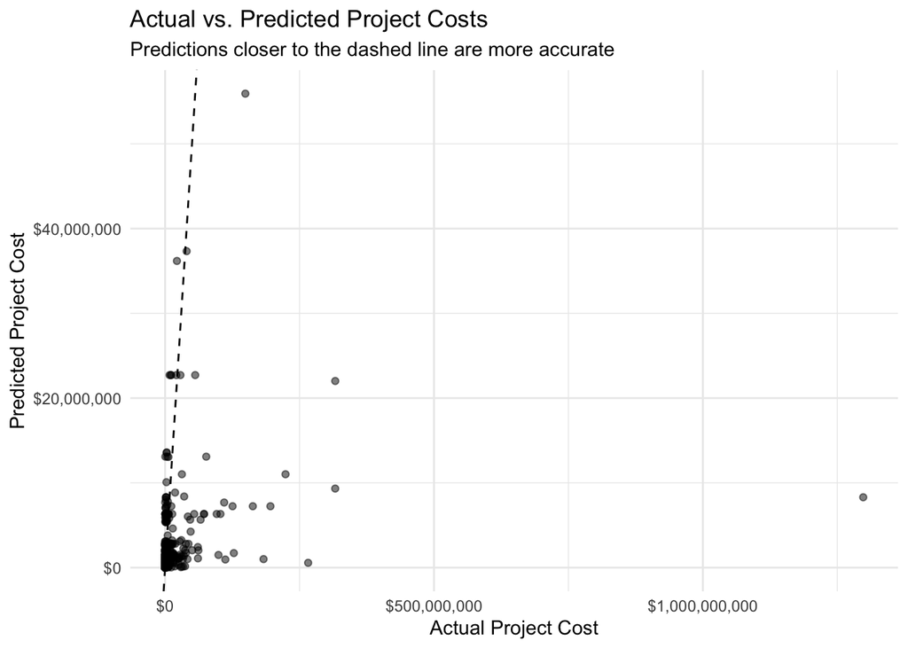

```r
# Plot actual project costs against the model's predictions
ggplot(
  validation_results,
  aes(x = actual, y = predicted)
) +
  geom_point(alpha = 0.5) +

  # The dashed line represents a perfect prediction
  geom_abline(
    intercept = 0,
    slope = 1,
    linetype = "dashed"
  ) +
  scale_x_continuous(labels = dollar_format()) +
  scale_y_continuous(labels = dollar_format()) +
  labs(
    title = "Actual vs. Predicted Project Costs",
    subtitle = "Predictions closer to the dashed line are more accurate",
    x = "Actual Project Cost",
    y = "Predicted Project Cost"
  ) +
  theme_minimal()
```

# Largest Prediction Errors

Overall accuracy is useful, but I also wanted to see where the model struggled the most. Looking at the largest errors can help identify projects that may be unusual or harder to predict using the available characteristics.

```r
validation_results <- validation_results |>
  mutate(
    # Positive error means the actual cost was higher than predicted
    error = actual - predicted,

    # Measure the size of the error regardless of direction
    absolute_error = abs(error),

    # Express the error relative to the project's actual cost
    percent_error = absolute_error / actual
  )
```

```r
# Display the 10 projects with the largest prediction errors
validation_results |>
  arrange(desc(absolute_error)) |>
  head(10)
```

```
##         actual  predicted      error absolute_error percent_error
## 287 1298192869  8302885.0 1289889984     1289889984     0.9936043
## 869  316300000  9329008.9  306970991      306970991     0.9705058
## 367  316375114 22020324.2  294354789      294354789     0.9303981
## 310  265974733   568335.1  265406398      265406398     0.9978632
## 536  223888000 11017856.8  212870143      212870143     0.9507885
## 75   195846313  7243848.7  188602464      188602464     0.9630126
## 101  183040000  1005672.8  182034327      182034327     0.9945057
## 398  163080000  7243848.7  155836151      155836151     0.9555810
## 352  127784001  1714398.8  126069602      126069602     0.9865836
## 257  125440000  7243848.7  118196151      118196151     0.9422525
```

# Conclusions

Rather than judging the model only by how well it fits the data used to build it, I tested it on a separate validation sample. This gives a better idea of how the model might perform when it encounters new projects.

This model is not meant to replace an engineer’s estimate. Instead, it shows how historical data could provide another point of reference when estimating costs and identifying projects that do not follow typical patterns.

# Data Source

Texas Department of Transportation (TxDOT), Project Information Open Data.